# Policyjne zabójstwa Amerykanów w 2015 roku - analiza eksporacyjna

Szymon Tlałka, Katarzyna Bortel

Czerwiec 2022

# Wprowadzenie

Celem projektu jest eksploracja danych o zabójtwach dokonanych przez policje w roku 2015. Dane pochodzą z brytyjskiego dziennika TheGuardian. Dane Guardiana zostały pobrane 2 czerwca 2015 r. Więcej informacji o jego bazie danych można znaleźć [tutaj](https://www.theguardian.com/us-news/ng-interactive/2015/jun/01/about-the-counted). Baza danych została także wzbogacona o dane z Amerykańskiego spisu statystycznego.

## Obróbka danych

Dane wczytano bezpośrednio z bazy dostępnej na [GitHubie](https://github.com/fivethirtyeight/data/tree/master/police-killings)

```r
police <- read.csv("https://raw.githubusercontent.com/fivethirtyeight/data/master/police-killings/police_killings.csv")
```

Baza zawiera 467 rekordów i 34 zmiennych. Każdy rekord zawiera informacje o jednej zabitej osobie.

## Wykorzystane zmienne

W dalszej analizie wykorzystano następujące zmienne:

| Zmienna | Opis |
| --- | --- |
| *gender* | płeć zabitego |
| *raceethnicity* | rasa/etniczność zabitego |
| *city* | miasto zabójstwa |
| *state* | stan |
| *cause* | przyczyna śmierci |
| *armed* | jak/czy zmarły był uzbrojony |

# Analizy

## Analiza Przestrzenna

Zacznijmy od analizy przestrzennej z podziałem na stany.  
Celem tej analizy jest sprawdzenie, czy można zaobserwować jakieś wzorce związane ze stanem.  
Liczba osób zabitych w danym stanie (10 stanów z największą liczbą)

```r
police.people <- police %>%
    group_by(state) %>%
    count(gender) %>%
    pivot_wider(names_from = gender, values_from = n, values_fill = 0) %>%
    mutate(suma = Male + Female) %>%
    arrange(desc(suma)) %>%
    head(n=10)

  knitr::kable(police.people, col.names=c("stan", "Mężczyźni","Kobiety","Suma"))
```

| stan | Mężczyźni | Kobiety | Suma |
| --- | --- | --- | --- |
| CA | 69 | 5 | 74 |
| TX | 44 | 2 | 46 |
| FL | 29 | 0 | 29 |
| AZ | 22 | 3 | 25 |
| OK | 22 | 0 | 22 |
| GA | 14 | 2 | 16 |
| NY | 14 | 0 | 14 |
| CO | 11 | 1 | 12 |
| IL | 11 | 0 | 11 |
| LA | 11 | 0 | 11 |

CA - Kalifornia, TX - Teksas, FL - Floryda, AZ - Arizona, Ok - Oklahoma, GA - Georgia, NY - Nowy Jork, CO - Kolorado, IL - Illinois, LA - Luizjana  
Stanem z największą liczbą ofiar jest Kalifornia, drugim Teksas a trzecim Floryda. Może to być spowodowane faktem iż stany te posiadają największą populacje dokładnie w takiej samej kolejności [źródło](https://en.wikipedia.org/wiki/List_of_U.S._states_and_territories_by_population)

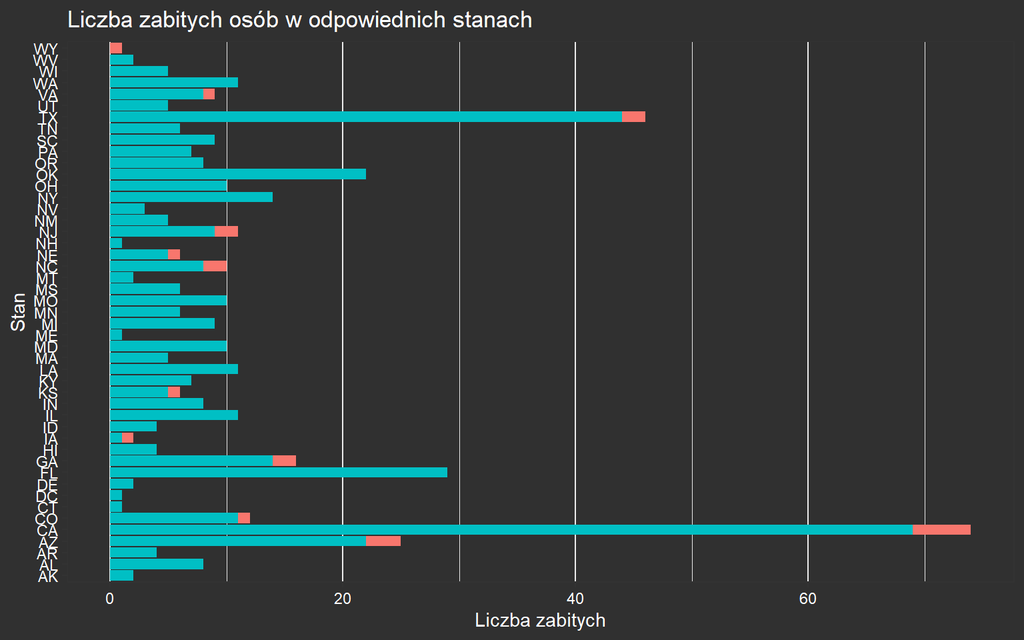

```r
police %>%
    ggplot(aes(x=state))+
    geom_bar(aes(fill=gender))+
    coord_flip()+
    theme_bw()+
    theme(legend.position="none")+theme(
    panel.background = element_rect(fill = 'gray19', colour = 'gray19'),
    plot.background = element_rect(fill = 'gray19', colour = 'gray19'),
    legend.background = element_rect(fill = 'gray19', colour = 'gray19'),
    axis.text = element_text(colour = "white"),
    legend.text = element_text(colour = "white"),
    legend.title = element_text(colour = "white"),
    axis.title.x = element_text(colour = "white"),
    axis.title.y = element_text(colour = "white"),
    plot.title = element_text(colour = "white"),
    panel.grid.major.y = element_blank())+
  ylab("Liczba zabitych")+
  xlab("Stan")+
  ggtitle("Liczba zabitych osób w odpowiednich stanach")
```

Wykres kolumnowy przedstawiający rozkład ofiar dla każdego stanu idealnie pokazuje, że większość ofiar stanowili mężczyzni.

```r
police.city <-   police %>%
    count(city,state) %>%
    arrange(desc(n)) %>%
    head(n=10)

knitr::kable(police.city, col.names=c("Miasto", "Stan","Liczba zdarzeń"))
```

| Miasto | Stan | Liczba zdarzeń |
| --- | --- | --- |
| Los Angeles | CA | 9 |
| Houston | TX | 6 |
| Phoenix | AZ | 6 |
| Indianapolis | IN | 4 |
| New York | NY | 4 |
| Oklahoma City | OK | 4 |
| San Francisco | CA | 4 |
| Tulsa | OK | 4 |
| Atlanta | GA | 3 |
| Austin | TX | 3 |

Miastem z największą liczbą zabójst (9) było Los Angeles w stanie Kalifornia, drugim (6) - Houston w stanie Teksas oraz Phoenix w stanie Arizona

## Sposób zabójstwa

W zbiorze danych możemy znaleźć inforamcje o tym w jaki sposób osoba została zabita.

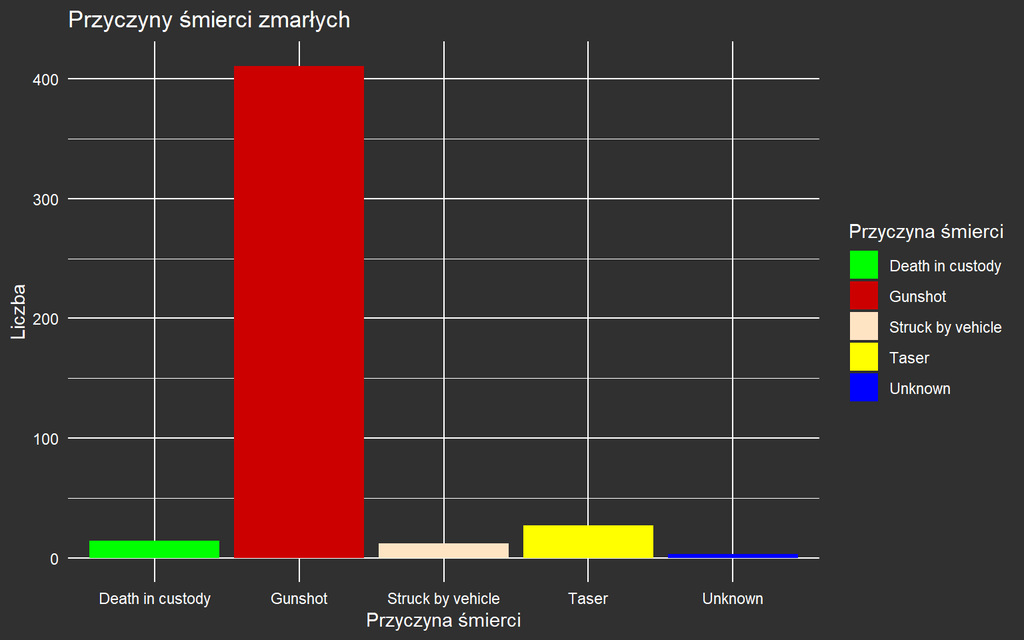

```r
police %>%
    count(cause) %>%
    ggplot(aes(x=cause, y=n))+
    geom_col(aes(fill=cause)) +
    xlab("Przyczyna śmierci") + ylab("Liczba")+
  scale_fill_manual(values =c("green","red3", "bisque", "yellow", "blue"))+
  theme(
    legend.key = element_rect(fill = "gray19"),
    panel.background = element_rect(fill = 'gray19', colour = 'gray19'),
    plot.background = element_rect(fill = 'gray19', colour = 'gray19'),
    legend.background = element_rect(fill = 'gray19', colour = 'gray19'),
    axis.text = element_text(colour = "white"),
    legend.text = element_text(colour = "white"),
    legend.title = element_text(colour = "white"),
    axis.title.x = element_text(colour = "white"),
    plot.title = element_text(colour = "white"),
    axis.title.y = element_text(colour = "white"))+
    labs(fill = "Przyczyna śmierci")+
    ggtitle("Przyczyny śmierci zmarłych")
```

```r
police.cause <- police %>%
    count(cause) %>%
    mutate(Percentage = (n/sum(n))*100)

  knitr::kable(police.cause, col.names=c("Przyczyna śmierci", "Liczba","Procent"))
```

| Przyczyna śmierci | Liczba | Procent |
| --- | --- | --- |
| Death in custody | 14 | 2.9978587 |
| Gunshot | 411 | 88.0085653 |
| Struck by vehicle | 12 | 2.5695931 |
| Taser | 27 | 5.7815846 |
| Unknown | 3 | 0.6423983 |

Możemy zaobserwować tutaj że przytłaczającą większość śmierci była spowodowana postrzałem broni palnej, Śmierć z powodu porażenia paralizatorem poniosło praktycznie tyle samo osób co przez pozostałe 3 sposoby.

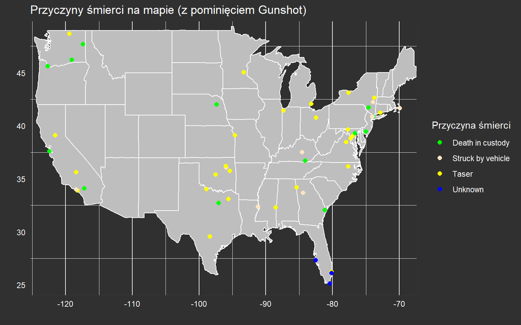

```r
police2 <- police %>%
  filter( cause != "Gunshot") %>%
  filter(longitude > -140)
us <- map_data("state")
  ggplot() +
    geom_map(data = us, map = us, aes(map_id = region) ,fill = "grey", color = "white") +
    geom_point(data = police2, aes(x = longitude, y = latitude, color = cause,), size = 2)+
    scale_color_manual(values =c("green", "bisque", "yellow", "blue"))+
    theme_bw()+
    theme(
      legend.key = element_rect(fill = "gray19"),
      panel.background = element_rect(fill = 'gray19', colour = 'gray19'),
      plot.background = element_rect(fill = 'gray19', colour = 'gray19'),
      legend.background = element_rect(fill = 'gray19', colour = 'gray19'),
      axis.text = element_text(colour = "white"),
      legend.text = element_text(colour = "white"),
      legend.title = element_text(colour = "white"),
      axis.title.x = element_text(colour = "white"),
      axis.title.y = element_text(colour = "white"),
      plot.title = element_text(colour = "white"),
      panel.grid.major.y = element_blank())+
      ylab("")+
      xlab("")+
      ggtitle("Przyczyny śmierci na mapie (z pominięciem Gunshot)")+
      guides(color=guide_legend(title="Przyczyna śmierci"))
```

Możemy tutaj zaobserwować że tylko na Florydzie zdarzają nieokreślone sposoby śmierci.

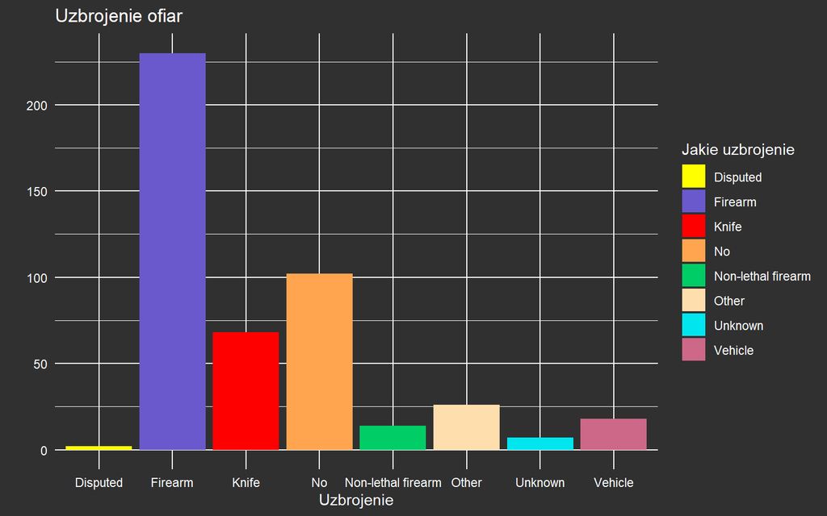

```r
police %>%
    count(armed) %>%
    arrange(desc(n)) %>%
    ggplot(aes(x=armed, y=n))+
    geom_col(aes(fill=armed))+
    xlab("Uzbrojenie") + ylab(" ")+
  scale_fill_manual(values =c("yellow1", "slateblue3", "red1", "tan1","springgreen3","navajowhite","turquoise2","palevioletred3"))+
    theme(
      legend.key = element_rect(fill = "gray19"),
      panel.background = element_rect(fill = 'gray19', colour = 'gray19'),
      plot.background = element_rect(fill = 'gray19', colour = 'gray19'),
      legend.background = element_rect(fill = 'gray19', colour = 'gray19'),
      axis.text = element_text(colour = "white"),
      legend.text = element_text(colour = "white"),
      legend.title = element_text(colour = "white"),
      axis.title.x = element_text(colour = "white"),
      plot.title = element_text(colour = "white"),
      axis.title.y = element_text(colour = "white"))+
      labs(fill = "Jakie uzbrojenie")+
      ggtitle("Uzbrojenie ofiar")
```

Możemy zobaczyć tutaj że najwięcej zmarłych było uzbrojonych w broń palną, drugą najliczniejszą grupe stanowiły osoby nieuzbrojone, a trzecią osoby uzbrojone w nóż.

```r
police.armed.race <- police %>%
    count(armed,raceethnicity) %>%
    arrange(desc(n)) %>%
    head(n=10)

  knitr::kable(police.armed.race, col.names=c("Uzbrojenie", "Pochodzenie","Liczba przypadków"))
```

| Uzbrojenie | Pochodzenie | Liczba przypadków |
| --- | --- | --- |
| Firearm | White | 120 |
| Firearm | Black | 66 |
| No | White | 51 |
| Knife | White | 32 |
| No | Black | 32 |
| Firearm | Hispanic/Latino | 31 |
| Knife | Black | 18 |
| Other | White | 15 |
| Knife | Hispanic/Latino | 14 |
| No | Hispanic/Latino | 13 |

Widać tutaj że najczęściej umierali ludzie pochodzenia białego, uzbrojeni w broń palną (120), zaraz po nich znajdują się ludzie pochodzenia czarnego, uzbrojeni w broń palną(66), trzecie miejsce zajmują ludzie pochodzenia białego nieuzbrojeni.

## Analiza Pochodzenia

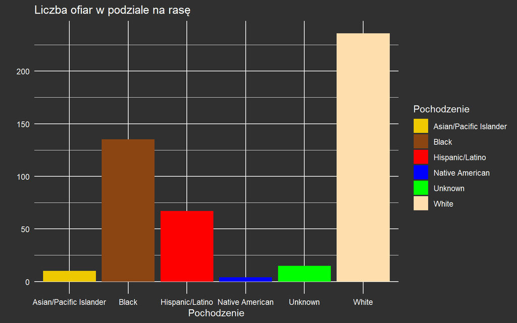

```r
police %>%
  count(raceethnicity) %>%
  ggplot(aes(x=raceethnicity, y=n))+
  geom_col(aes(fill=raceethnicity))+
  scale_fill_manual(values =c("gold2", "saddlebrown", "red", "blue","green","navajowhite"))+
  theme(
    legend.key = element_rect(fill = "gray19"),
    panel.background = element_rect(fill = 'gray19', colour = 'gray19'),
    plot.background = element_rect(fill = 'gray19', colour = 'gray19'),
    legend.background = element_rect(fill = 'gray19', colour = 'gray19'),
    axis.text = element_text(colour = "white"),
    legend.text = element_text(colour = "white"),
    legend.title = element_text(colour = "white"),
    axis.title.x = element_text(colour = "white"),
    plot.title = element_text(colour = "white"),
    axis.title.y = element_text(colour = "white"))+
  ylab("")+
  xlab("Pochodzenie")+
  ggtitle("Liczba ofiar w podziale na rasę")+
  labs(fill = "Pochodzenie")
```

Z wykresu możemy odczytać, że najwięcej ofiar to osoby rasy białej, dużo niżej znajdują się osoby rasy czarnej

```r
police.kill <- police %>%
    count(raceethnicity) %>%
    mutate(Percentage = (n/sum(n))*100)

knitr::kable(police.kill, col.names=c("Pochodzenie", "Liczba","Procent"))
```

| Pochodzenie | Liczba | Procent |
| --- | --- | --- |
| Asian/Pacific Islander | 10 | 2.141328 |
| Black | 135 | 28.907923 |
| Hispanic/Latino | 67 | 14.346895 |
| Native American | 4 | 0.856531 |
| Unknown | 15 | 3.211991 |
| White | 236 | 50.535332 |

Najwięcej osób które zginęły było pochodzenia białego, drugą najlczniejszą grupe stanowiły pochodzenia czarnego, a trzecią grupe stanowiły osoby pochodzenia latynoskiego

Mapa pokazująca w jakich miejscach zostały zabite osoby danego pochodzenia (dla większej czytelności pominięto incydenty z Hawajów i Alaski)

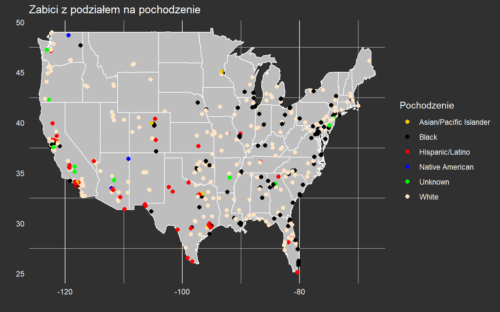

```r
  police1 <- police %>%
    filter(longitude > -140)

  us <- map_data("state")
  ggplot() +
    geom_map(data = us, map = us, aes(map_id = region) ,fill = "grey", color = "white") +
    geom_point(data = police1, aes(x = longitude, y = latitude, color = raceethnicity,), size = 2)+
    scale_color_manual(values =c("gold2", "black", "red", "blue","green","bisque"))+
    theme_bw()+
    theme(
      legend.key = element_rect(fill = "gray19"),
      panel.background = element_rect(fill = 'gray19', colour = 'gray19'),
      plot.background = element_rect(fill = 'gray19', colour = 'gray19'),
      legend.background = element_rect(fill = 'gray19', colour = 'gray19'),
      axis.text = element_text(colour = "white"),
      legend.text = element_text(colour = "white"),
      legend.title = element_text(colour = "white"),
      axis.title.x = element_text(colour = "white"),
      axis.title.y = element_text(colour = "white"),
      plot.title = element_text(colour = "white"),
      panel.grid.major.y = element_blank())+
    ylab("")+
    xlab("")+
    ggtitle("Zabici z podziałem na pochodzenie")+
    guides(color=guide_legend(title="Pochodzenie"))
```

Na mapie możemy zaobserwować że większość osób pochodzenia Latynoskiego zginęło w południowo - zachodniej części kraju. Wpływ na to mogła mieć chęć emigracji z graniczącego ze Stanami Meksyku. Zgony osób pochodzenia białego rozłożone są jednorodnie po całym kraju. Możemy jednak zauważyć iż bardziej na wschód tym bardziej można zaobserwować zgony osób pochodzenia czarnoskórego.

# Wnioski

1. Analiza przestrzenna wykazuje, że najwięcej zabójstw zostało dokonanych w trzech najbardziej zaludnionych stanach w kolejności odpowiedniej do liczby ludności zamieszkującej dany stan.
2. Aż 88% zostaje zastrzelonych.
3. W analizie przestrzennej możemy zauważyć dziwną zależność, że tylko na Florydzie występują nieokreślone sposoby śmierci. Osoby białe są zabijane w całej Ameryce, za to latynosi głównie w południowo-zachodniej części kraju a osoby czarnoskóre na wschodzie.
4. Procentowo najwięcej zabija się osób rasy białej.

# Co dalej

Dalsze analizy mogłyby uwzględnić:  
1. Sprawdzenie jaki procentowy udział mają ofiary danej rasy w stosunku do wszystkich osób tej rasy mieszkających w USA.  
2. Analizę zamożności ofiar.  
3. Analiza wieku ofiar.

### Źródła danych i wykorzystane pomoce:

-https://github.com/fivethirtyeight/data/tree/master/police-killings  
-https://www.theguardian.com/us-news/ng-interactive/2015/jun/01/about-the-counted  
- https://en.wikipedia.org/wiki/List_of_U.S._states_and_territories_by_population